# Analyzing Las Vegas’ Car Accident Injuries

Poission Regression

Nick Broussard

04 February 2020

## Explore and Clean

First, read in the dataset.

Second, select variables.

Third, look at the dataframe’s structure…

Observations: 37,086 Variables: 4 $ Injured 0, 2, 1, 1, 1, 2, 1, 1, 2, 1, 1, 0, 0, 1, 2, 2, 1, 1, 1,… $ Crash_Date “2015-02-03T00:00:00.000Z”, “2015-01-06T00:00:00.000Z”, … $ Crash_Time “2019-10-23T19:00:00.000Z”, “2019-10-23T09:52:00.000Z”, … $ Weather “CLEAR”, “CLEAR”, “CLEAR”, “CLEAR”, “CLEAR”, "CLOUDY: RA…

…and convert variables accordingly.

Fourth, inspect the categorical.

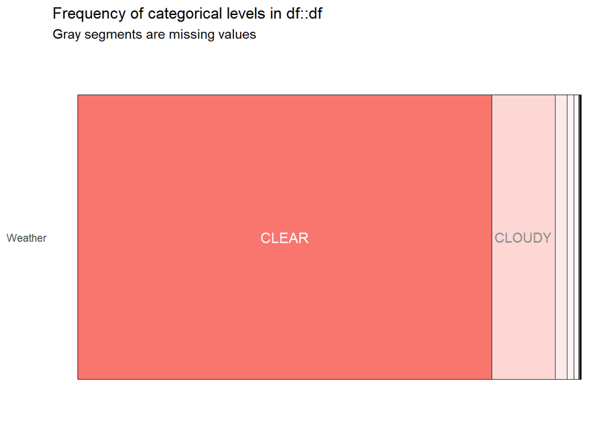

Based on this distribution…

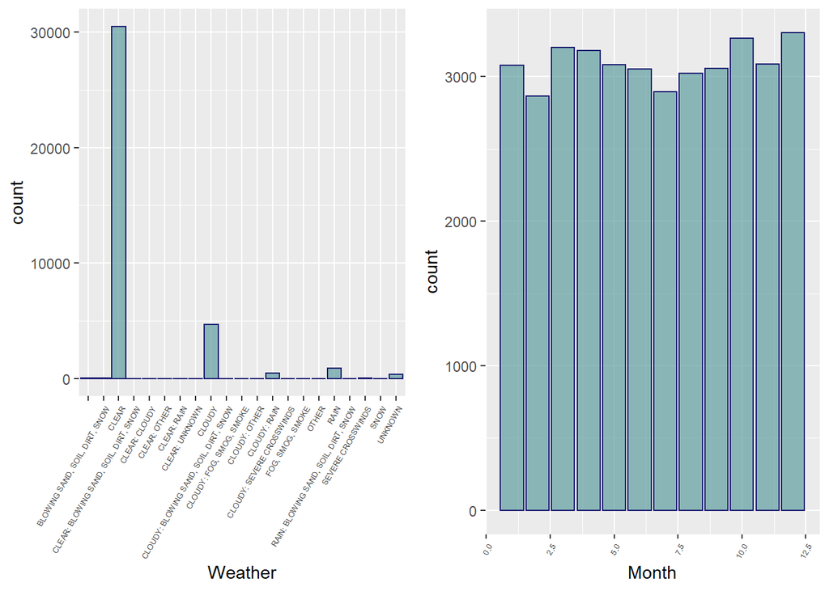

…restrict.

Fifth, inspect numerics by calling the 5-number-summary…

|  | Min | Q1 | Median | Q3 | Max |
| --- | --- | --- | --- | --- | --- |
| **Hour** | 0.00 | 900.00 | 1400.00 | 1700.00 | 2300.00 |
| **Injured** | 0.00 | 0.00 | 0.00 | 1.00 | 13.00 |
| **Month** | 1.00 | 4.00 | 7.00 | 10.00 | 12.00 |

…and histogram distributions (dependent variable should have a poisson distribution, predictor should be uniform)…

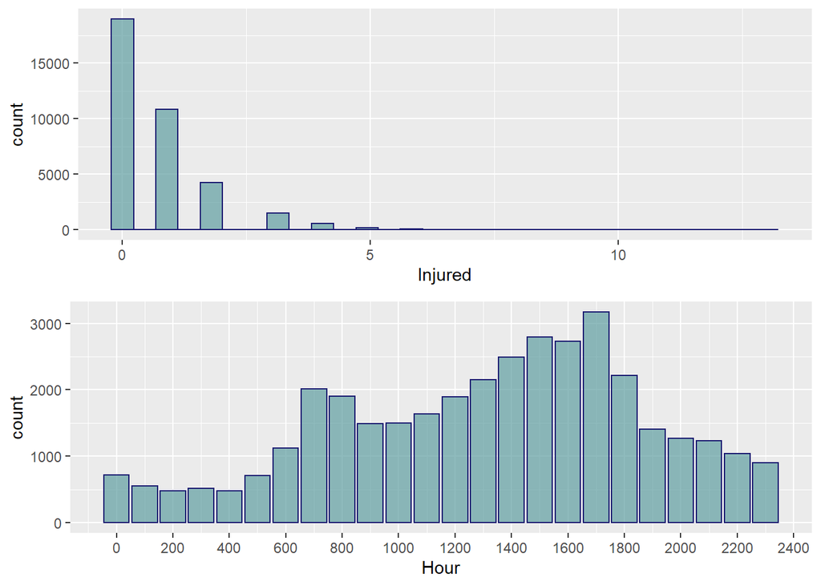

…and for outliers (any value > 1.5*IQR).

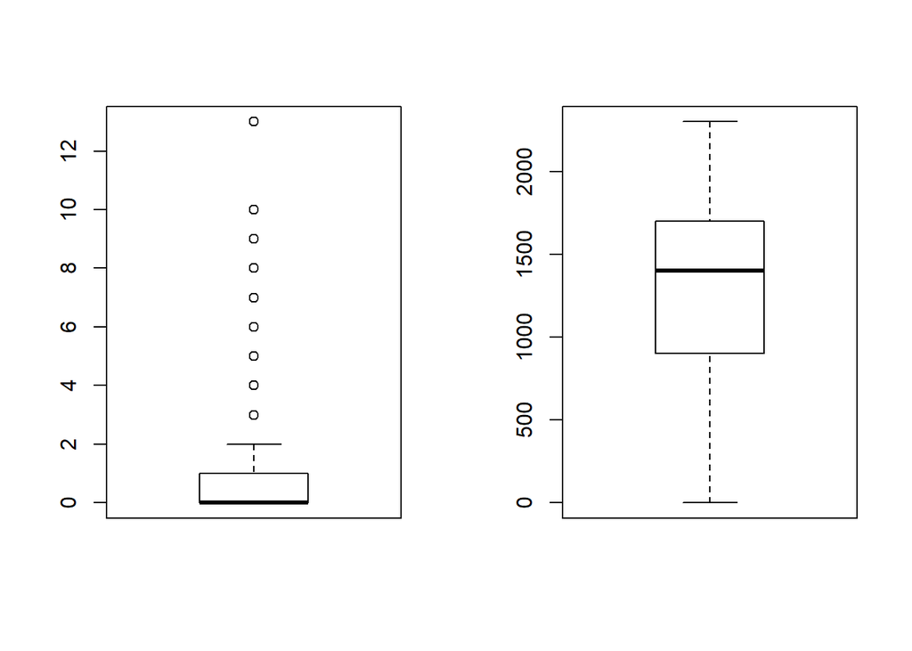

There are no outliers in the continuous predictor variable.

Sixth, check missingness…

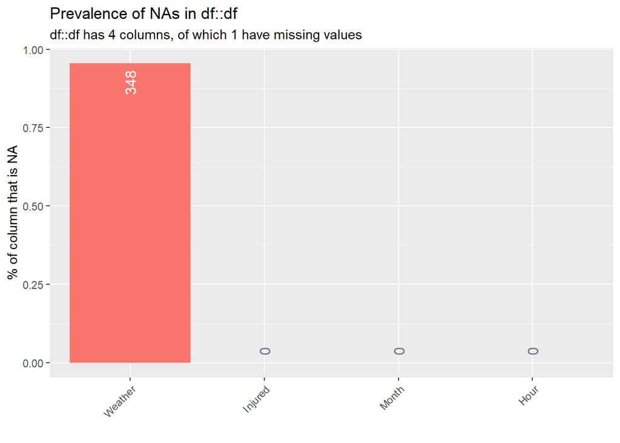

…and impute.

Seventh, and finally, check correlation between the continuous variables.

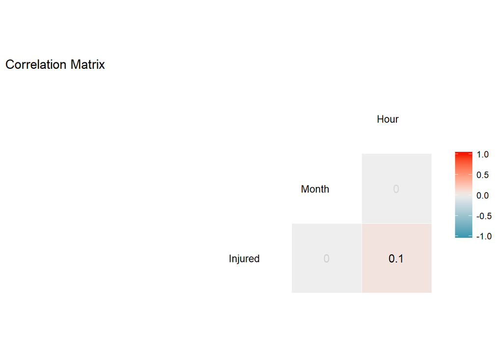

We actually only need to check for multicolinearity (coefficient of correlation > .6) between predictor variables.

## Model

First, split the data.

Second, build and run the model.

Use exponentiated coefficients (read as odds instead of log odds).

| Observations | 18208 |
| --- | --- |
| Dependent variable | Injured |
| Type | Generalized linear model |
| Family | poisson |
| Link | log |

| χ²(4) | 152.5896 |
| --- | --- |
| Pseudo-R² (Cragg-Uhler) | 0.0092 |
| Pseudo-R² (McFadden) | 0.0034 |
| AIC | 44095.1099 |
| BIC | 44134.1579 |

|  | exp(Est.) | 2.5% | 97.5% | z val. | p |
| --- | --- | --- | --- | --- | --- |
| (Intercept) | 0.5881 | 0.5561 | 0.6220 | -18.5727 | 0.0000 |
| WeatherCLOUDY | 1.0239 | 0.9746 | 1.0756 | 0.9383 | 0.3481 |
| WeatherRAIN | 0.8077 | 0.7176 | 0.9092 | -3.5381 | 0.0004 |
| Month | 1.0018 | 0.9969 | 1.0066 | 0.7080 | 0.4789 |
| Hour | 1.0002 | 1.0001 | 1.0002 | 11.5204 | 0.0000 |

Standard errors: MLE

Model: $\ y=0.59+1.02*Cloudy+0.80*Rainy+1*Month+1*Hour$

Third, conduct graphical analysis. Analyze the coefficient effects…

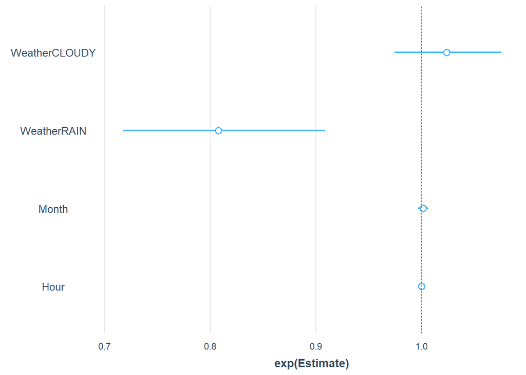

…then vizualize the relationshp between each predictor and the dependent variable.

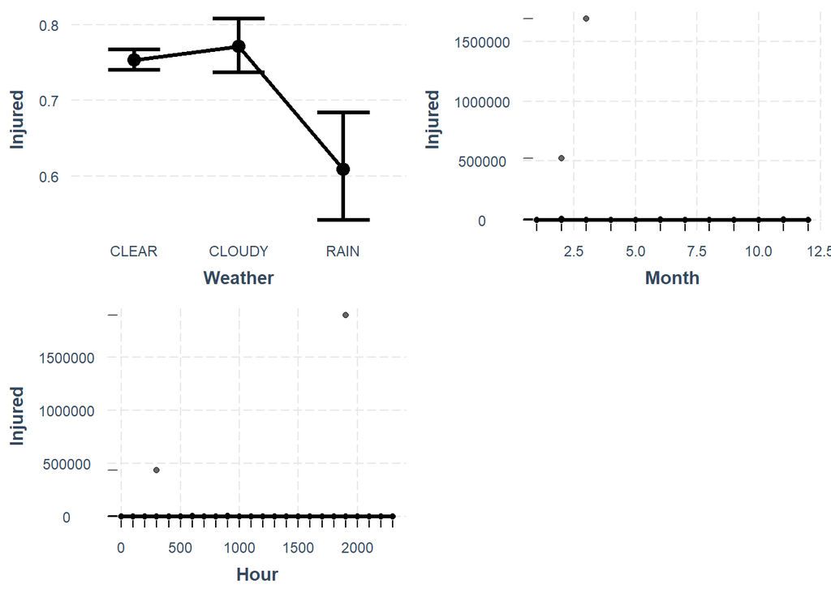

Fourth, pull in fitted and residual values…

…and query the model.

- What is the average number of injured passengers per accident at 1600 each day? 0.7792345

Fifth, evaluate goodness of fit.

[1] 1.323537

Overdispersion test

data: model z = 17.434, p-value < 2.2e-16 alternative hypothesis: true alpha is greater than 0 sample estimates: alpha 0.3742562

[1] 1.727782e-173

## Compare

| Observations | 18208 |
| --- | --- |
| Dependent variable | Injured |
| Type | Generalized linear model |
| Family | quasipoisson |
| Link | log |

| χ²(4) | 152.5896 |
| --- | --- |
| Pseudo-R² (Cragg-Uhler) | 0.0092 |
| Pseudo-R² (McFadden) | 0.0034 |
| AIC | NA |
| BIC | NA |

|  | exp(Est.) | 2.5% | 97.5% | t val. | p |
| --- | --- | --- | --- | --- | --- |
| (Intercept) | 0.5881 | 0.5507 | 0.6280 | -15.8424 | 0.0000 |
| WeatherCLOUDY | 1.0239 | 0.9664 | 1.0847 | 0.8003 | 0.4235 |
| WeatherRAIN | 0.8077 | 0.7031 | 0.9279 | -3.0180 | 0.0025 |
| Month | 1.0018 | 0.9961 | 1.0075 | 0.6040 | 0.5459 |
| Hour | 1.0002 | 1.0001 | 1.0002 | 9.8268 | 0.0000 |

Standard errors: MLE

Goodness of fit for quasi-poisson.

Overdispersion test

data: model z = 17.069, p-value < 2.2e-16 alternative hypothesis: true alpha is greater than 0 sample estimates: alpha 0.2722279

Negative binomial.

| Observations | 18208 |
| --- | --- |
| Dependent variable | Injured |
| Type | Generalized linear model |
| Family | Negative Binomial(2.1127) |
| Link | log |

[output not shown]

|  | exp(Est.) | 2.5% | 97.5% | z val. | p |
| --- | --- | --- | --- | --- | --- |
| (Intercept) | 0.5858 | 0.5491 | 0.6250 | -16.1753 | 0.0000 |
| WeatherCLOUDY | 1.0249 | 0.9675 | 1.0858 | 0.8377 | 0.4022 |
| WeatherRAIN | 0.8048 | 0.7034 | 0.9207 | -3.1629 | 0.0016 |
| Month | 1.0017 | 0.9961 | 1.0074 | 0.5947 | 0.5520 |
| Hour | 1.0002 | 1.0001 | 1.0002 | 10.0935 | 0.0000 |

Standard errors: MLE

Goodness of fit for negative binomial.

Likelihood ratio test of H0: Poisson, as restricted NB model: n.b., the distribution of the test-statistic under H0 is non-standard e.g., see help(odTest) for details/references

Critical value of test statistic at the alpha= 0.05 level: 2.7055 Chi-Square Test Statistic = 869.6163 p-value = < 2.2e-16

Compare the models based on coefficients and variance.

|  | Model 1 | Model 2 | Model 3 |
| --- | --- | --- | --- |
| (Intercept) | -0.5308 *** | -0.5308 *** | -0.5347 *** |
|  | (0.0286) | (0.0335) | (0.0331) |
| WeatherCLOUDY | 0.0236 | 0.0236 | 0.0246 |
|  | (0.0251) | (0.0295) | (0.0294) |
| WeatherRAIN | -0.2135 *** | -0.2135 ** | -0.2172 ** |
|  | (0.0604) | (0.0708) | (0.0687) |
| Month | 0.0018 | 0.0018 | 0.0017 |
|  | (0.0025) | (0.0029) | (0.0029) |
| Hour | 0.0002 *** | 0.0002 *** | 0.0002 *** |
|  | (0.0000) | (0.0000) | (0.0000) |
| N | 18208 | 18208 | 18208 |
| AIC | 44095.1099 |  | 43227.4935 |
| BIC | 44134.1579 |  | 43274.3512 |
| Pseudo R2 | 0.0092 | 0.0092 | 0.0069 |
| *** p < 0.001; ** p < 0.01; * p < 0.05. |  |  |  |

| Resid. Df | Resid. Dev | Df | Deviance |
| --- | --- | --- | --- |
| 1.82e+04 | 2.41e+04 |  |  |
| 1.82e+04 | 2.41e+04 | 0 | 0 |
| 1.82e+04 | 1.83e+04 | 0 | 5.78e+03 |

## Sources

- Negative Binomial Regression: https://stats.idre.ucla.edu/r/dae/negative-binomial-regression/
- Deviance Goodness of Fit: https://thestatsgeek.com/2014/04/26/deviance-goodness-of-fit-test-for-poisson-regression/
- Overdispersion Tests: https://stats.stackexchange.com/questions/66586/is-there-a-test-to-determine-whether-glm-overdispersion-is-significant